```python
import pymc3 as pm
import pandas as pd
import numpy as np
import matplotlib.pyplot as plt
import seaborn as sns
import scipy.stats as st
```

```python
np.random.seed(20181027)
```

# Introduction

The goal is to estimate the "health" of network communication in a medium that is unreliable (messages get dropped) and are out of our control. That means we cannot just physically inspect the system, instead we have to rely on measurements on our side (delay between point #1 and point #2) to estimate this.

In the end there are two hidden variables we are interested in:

- Probability of packets getting dropped
- (Optionally) Given a specific message with some delay, estimated number of drops.

# Load and view data

The data contains one-way-delays (OWD) between two endpoints over the day as a one-dimensional array. The actual timestamps are stripped out so the data only contains the relative delays.

```python
data = np.loadtxt('owd.csv')
```

If we simply do a scatterplot over the order of occurrance we can see some bands appearing:

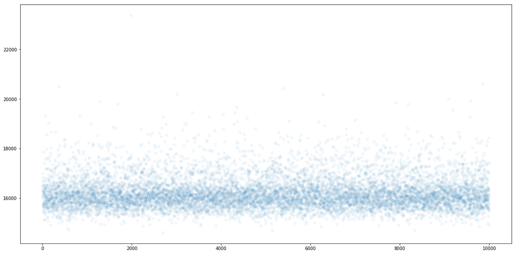

```python
plt.figure(figsize=[20, 10])
plt.scatter(y=data, x=np.arange(0, len(data)), alpha=.05)
```

If we plot the distribution, we can see multiple modes, which suggest that it is a mixture of distributions.

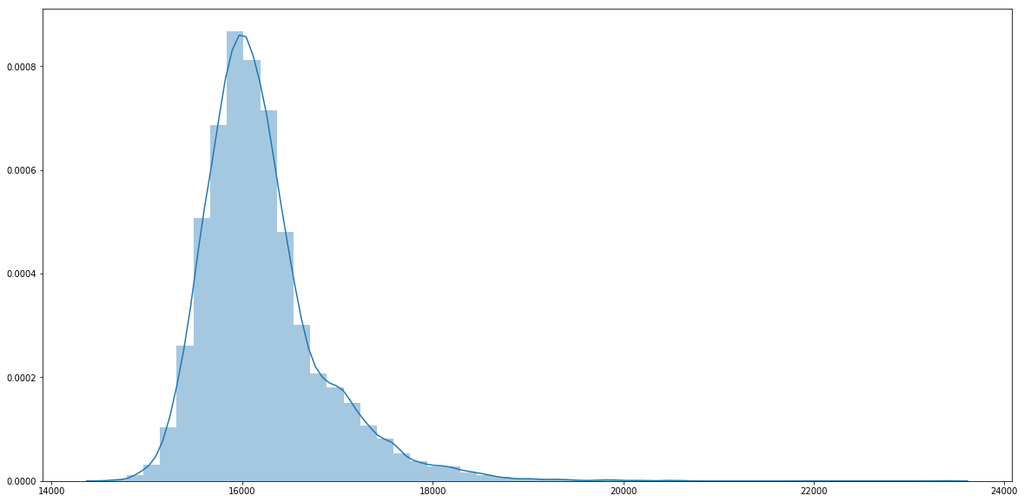

```python
plt.figure(figsize=[20, 10])
sns.distplot(data, kde=True)
```

# Knowledge

## Model

The model as mentioned in the slides:

[figure not shown]

Note that $n \times d2$ above is a simplification, which we extend below.

### Variables

- Hidden variable we are trying to find
  - $p_{drop}$ (between 10-40%)
- Random variable - known parameters:
  - $d1$, $d3$, $d2$
- Random variable - known distribution, unknown parameters:
  - $p_{drop}$ - Probability of dropping
  - $N_{tries} ~ Geo(1-p_{drop})$ - Total number of tries
  - $d2_{p} = d2_{1} + ... + d2_{N_{tries}}$ - Total latency at path d2
- Data:
  - D = $L_1 + L_2$ + $L_3$

# Knowledge

```python
NOBS = 10000
PATH1_MEAN = 10000
PATH1_STD = 250


PATH2_MEAN = 1000
PATH2_STD = 100

PATH3_MEAN = 5000
PATH3_STD = 250
```

# Approach 1: Modelling using Gaussian Mixture and a Dirichlet Prior

## Approximations and taking advantage of the distribution

There are two properties in the model that we can take advantage of: path #2 is a mixture of normal random variables, and the overall latency is a sum of normal mixture and two normal r.v.s, which in turn is a Normal mixture. The tricky part is that the mixture has infinite number of components (as it is given by the Geometric distribution), but we can approximate by assuming a maximum number of tries (and #component). Here we assume a distribution with $#components = 10$, which, in the worst case scenario captures $1 - (0.6 \times 0.4^9) \approx 99.99\%$ of the cases:

$D \sim \text{NormalMixture}(\mu, \sigma, w)$, with 10 components, where $\mu$ and $\sigma$ are determined by the number of tries and w is determined by the geometric distribution.

$\mu_i$ = $mu_{d1} + mu_{d3} + i \times mu_{d2} $

$\sigma_i$ = $\sqrt(sigma_{d1}^2 + sigma_{d3}^2 + i \times sigma_{d2}^2 )$

$w_i = (1-p_{drop}) - (p_{drop})^(i-1) $

After trying out different configurations, the most stable solution turned out to be to create a model as a Gaussian Mixture with Dirichlet prior, and then check the weights of the distribution with a potential that rewards Geometric distributions. This seemed more stable than, for instance, having a Geometric r.v. with a Beta prior which determines the weights of the Gaussian mixture.

```python
import theano
from pymc3 import model_to_graphviz

with pm.Model() as model_dirichlet:
  N = len(data)

  max_tries = 10
  all_tries = theano.shared(np.arange(1, max_tries+1, 1))


  weights = pm.Dirichlet('weights', np.ones(max_tries))

  owd_std = pm.math.sqrt((all_tries*(PATH2_STD**2) + PATH1_STD**2  + PATH3_STD**2) )
  owd_mean = PATH2_MEAN*all_tries + PATH1_MEAN + PATH3_MEAN

  owd = pm.NormalMixture(name='owd', mu=owd_mean, sd=owd_std, w=weights, observed=data, comp_shape=[N, max_tries])
  posterior_check = pm.NormalMixture(name='posterior_check', mu=owd_mean, sd=owd_std, w=weights)

  p_success = pm.Deterministic(name='p_s', var=weights[0])
  p2 = weights[1]


  # Assume geometric distribution based on the first component of the Gaussian Mixture
  expected_geo_p = p_success * (1-p_success)**all_tries
  expected_geo_p = expected_geo_p[1:]
  geo_check = pm.Potential('geo_potential', pm.Normal.dist(mu=expected_geo_p, sd=1/float(np.sqrt(N))).logp(weights[1:]))


  trace_dirichlet = pm.sample(8000, tune=500, parallelize=True, step=pm.Metropolis())
```

```
Multiprocess sampling (4 chains in 4 jobs)
CompoundStep
>Metropolis: [posterior_check]
>Metropolis: [weights]
The gelman-rubin statistic is larger than 1.4 for some parameters. The sampler did not converge.
The estimated number of effective samples is smaller than 200 for some parameters.
```

```python
pm.stats.summary(trace_dirichlet, ['p_s', 'weights'])
```

|  | mean | sd | mc_error | hpd_2.5 | hpd_97.5 | n_eff | Rhat |
| --- | --- | --- | --- | --- | --- | --- | --- |
| p_s | 0.837430 | 0.004209 | 0.000081 | 8.290283e-01 | 0.845336 | 2390.131313 | 1.000376 |
| weights__0 | 0.837430 | 0.004209 | 0.000081 | 8.290283e-01 | 0.845336 | 2390.131313 | 1.000376 |
| weights__1 | 0.128444 | 0.004111 | 0.000083 | 1.208168e-01 | 0.136356 | 2007.421622 | 1.000268 |
| weights__2 | 0.029253 | 0.002210 | 0.000090 | 2.507955e-02 | 0.033666 | 291.497218 | 1.010156 |
| weights__3 | 0.002865 | 0.001141 | 0.000097 | 3.462617e-06 | 0.004440 | 23.832445 | 1.070813 |
| weights__4 | 0.001351 | 0.000560 | 0.000046 | 4.657184e-04 | 0.002545 | 22.312885 | 1.079869 |
| weights__5 | 0.000166 | 0.000150 | 0.000013 | 4.436211e-06 | 0.000475 | 26.715683 | 1.007422 |
| weights__6 | 0.000107 | 0.000106 | 0.000009 | 2.275995e-06 | 0.000296 | 48.786623 | 1.003040 |
| weights__7 | 0.000120 | 0.000166 | 0.000016 | 2.047315e-08 | 0.000476 | 3.661688 | 1.707958 |
| weights__8 | 0.000110 | 0.000115 | 0.000010 | 7.043729e-07 | 0.000351 | 5.035438 | 1.454498 |
| weights__9 | 0.000154 | 0.000151 | 0.000013 | 1.018002e-06 | 0.000406 | 31.492551 | 1.050134 |

```python
model_to_graphviz(model_dirichlet)
```

[figure not shown]

```
array([[<matplotlib.axes._subplots.AxesSubplot object at 0x7fdc70070fd0>,
      dtype=object)
```

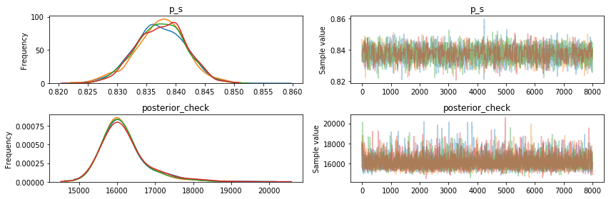

```python
pm.traceplot(trace_dirichlet, varnames=['p_s', 'posterior_check'])
```

## Compare data to posterior sample

We already used posterior_check to generate a posterior sample during model generation, but a better way is to use sample_ppc (to be renamed to sample_posterior_predictive) method to draw samples after the model is set already. This can be used to sanity check the model against the data, and for future predictions. It is suggested to use this to have a better holistic understanding of the model rather than hypothesis testing.

(See https://docs.pymc.io/notebooks/posterior_predictive.html)

```python
with model_dirichlet:
  ppc = pm.sample_ppc(trace_dirichlet, 1)
```

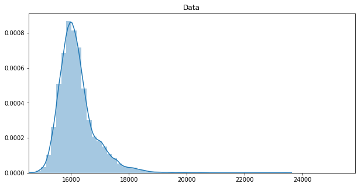

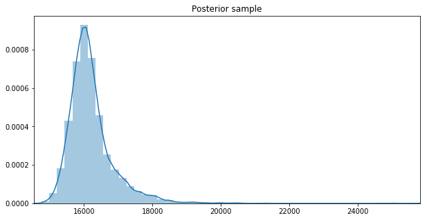

```python
post_sample = ppc['owd'][0]


plt.figure(figsize=[10, 5])
plt.title('Data')
sns.distplot(data, kde=True)
plt.xlim(min(post_sample), max(post_sample))

plt.figure(figsize=[10, 5])
plt.title('Posterior sample')
sns.distplot(post_sample, kde=True)
_=plt.xlim(min(post_sample), max(post_sample))
```

# Approach #2: Priors from Geometric distribution

This approach attempts to construct the Gaussian mixture directly from p_success. The advantage is that it can also estimate number of attempts associated with each latency. The downside is that it will take longer to sample.

Unlike the first approach, the categorical part (index/num_tries) is not marginalized.

```python
#Priors

means = PATH2_MEAN*all_tries + PATH1_MEAN + PATH3_MEAN
stds = np.sqrt(all_tries*(PATH2_STD**2) + PATH1_STD**2  + PATH3_STD**2)

data_sample = np.random.choice(data, 500)
with pm.Model() as model_latent:
  N = len(data_sample)

  max_tries = 10


  # Components of the mixture
  owd_mean = PATH2_MEAN*all_tries + PATH1_MEAN + PATH3_MEAN
  owd_std = pm.math.sqrt(all_tries*(PATH2_STD**2) + PATH1_STD**2  + PATH3_STD**2)


  # Hidden configuration - variables that are constant for the day but unknown
  P_SUCCESS = pm.Beta('p_s', mu=0.7, sd=0.1, testval=0.5)


  num_tries_test = np.random.choice(np.arange(1,10), size=N)

  # p_tries - Geometrically distributed with a cut-off of 10
  p_tries  = (P_SUCCESS)*((1-P_SUCCESS)**(all_tries-1))

  index = pm.Categorical('index', p=p_tries, shape=N, testval=num_tries_test)
  index_pred = pm.Categorical('index_pred', p=p_tries, testval=2)

  num_tries = pm.Deterministic('num_tries', index+1)


  owd = pm.Normal(name='owd', mu=owd_mean[index], sd=owd_std[index], observed=data_sample)

  predictive = pm.Normal(name='posterior_check', mu=owd_mean[index_pred], sd=owd_std[index_pred], testval=15000)

pm.model_to_graphviz(model_latent)
```

[figure not shown]

```python
with model_latent:
  step_float = pm.Metropolis(vars=[P_SUCCESS, predictive])
  trace_latent = pm.sample(5000,  tune=1000, parallelize=True, step=[step_float] )
```

```
Multiprocess sampling (4 chains in 4 jobs)
CompoundStep
>CompoundStep
>>Metropolis: [posterior_check]
>>Metropolis: [p_s]
>CategoricalGibbsMetropolis: [index_pred, index]
The number of effective samples is smaller than 10% for some parameters.
```

```
array([[<matplotlib.axes._subplots.AxesSubplot object at 0x7fdc910b2518>,
      dtype=object)
```

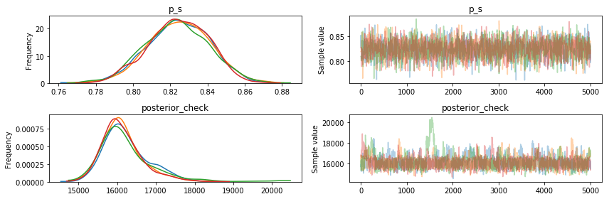

```python
pm.traceplot(trace_latent, varnames=['p_s', 'posterior_check'])
```

```python
pm.stats.summary(trace_latent, ['p_s'])
```

```
The history saving thread hit an unexpected error (OperationalError('database is locked',)).History will not be written to the database.
```

|  | mean | sd | mc_error | hpd_2.5 | hpd_97.5 | n_eff | Rhat |
| --- | --- | --- | --- | --- | --- | --- | --- |
| p_s | 0.82438 | 0.016616 | 0.000342 | 0.79282 | 0.85629 | 2200.946323 | 1.00055 |

```python
with model_latent:
  ppc_latent = pm.sample_ppc(trace_latent, 1)
```

## Compare data to posterior sample

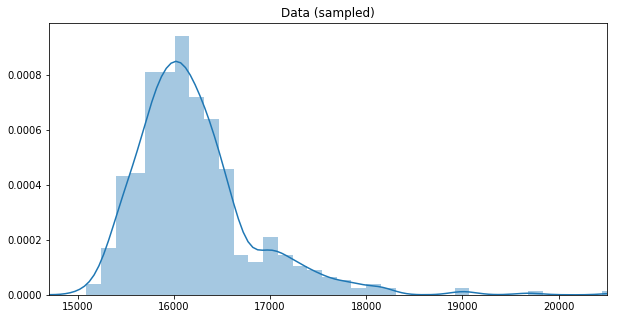

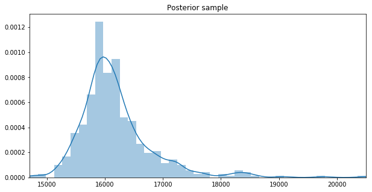

```python
post_sample = ppc_latent['owd'][0]


plt.figure(figsize=[10, 5])
plt.title('Data (sampled)')
sns.distplot(data_sample, kde=True)
plt.xlim(min(post_sample), max(post_sample))

plt.figure(figsize=[10, 5])
plt.title('Posterior sample')
sns.distplot(post_sample, kde=True)
_=plt.xlim(min(post_sample), max(post_sample))
```

## Predicted number of tries for data points for a given data point

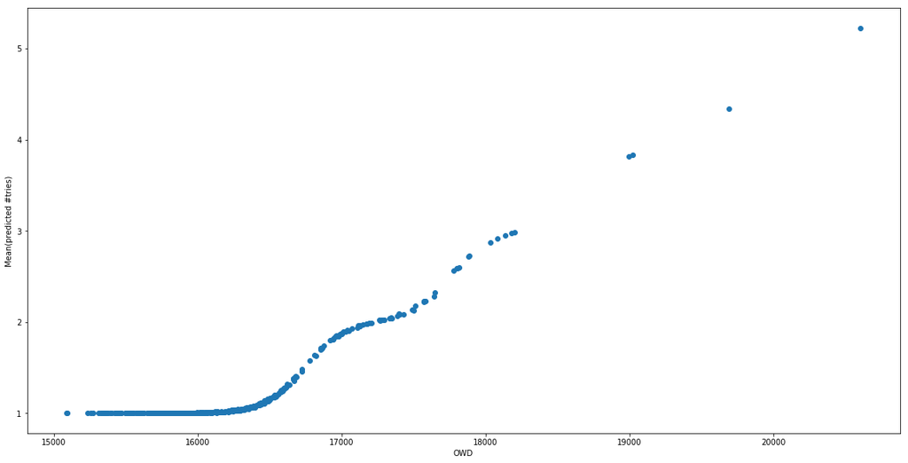

```python
plt.figure(figsize=[20, 10])
plt.scatter(x=data_sample, y=trace_latent['num_tries'].mean(0))
plt.xlabel('OWD')
_ = plt.ylabel('Mean(predicted #tries)')
```

# Remarks

While there are limitations, such as having to express the problem in terms of random variables, limitations on the parameter search space based on the geometry, and implementation/debugging; this approach allows us to model relatively complex problems in few lines of code.

Marginalizing the index parameter and directly using a Gaussian Mixture allows for faster convergence and tighter confidence intervals on the paramater p_s. On the other hand, it allows us to have prediction on individual #tries per case.

In the end, with both approaches, just by looking at the delays, we can have a reasonable estimate of the hidden variable, i.e. probability of success.

## Differences from the slides

- Fixed a bug in the simulation which was generating lower variance than intended, and re-generated the synthetic dataset. The bug had caused the model to under-estimate p_s by 2% in the previous analysis.
- Original analysis shown in the slides omits the geometric check for simplicity. Adding the potential allowed us to have an estimate of p_s closer to the true value.